# Project: Investigate a Dataset (European Soccer Database)

- Introduction
- Data Wrangling
- Exploratory Data Analysis
- Q1: What teams improved the most over the time period?
- Q2: Which players had the most penalties?
- Q3: What team attributes lead to the most victories?
- Conclusions

## Introduction

This soccer database comes from Kaggle and is well suited for data analysis and machine learning. It contains data for soccer matches,players, and teams from several European countries from 2008 to 2016. This dataset is quite extensive, and we encourage you to read more about it here.

**note:** I imported the data using sqlite then saved the needed output in csv files for easier analysis so I commented all the sql code after connecting and running the queries

Questions:

- Q1: What teams improved the most over the time period?
- Q2: Which players had the most penalties?
- Q3: What team attributes lead to the most victories?

```python
import pandas as pd
import numpy as np
import sqlite3 as sql
import matplotlib.pyplot as plt
import seaborn as sns
%matplotlib inline
```

## Data Wrangling

### General Properties

```python
# connecting the data base through sqlite
db=sql.connect('database.sqlite')

# this query gets the team table joined with the team attributes table

# teams_query=""" select DISTINCT t.team_long_name team,ta.date date,ta.buildUpPlaySpeed,ta.buildUpPlayDribbling,ta.buildUpPlayPassing from team t
#                    join Team_Attributes ta on ta.team_api_id=t.team_api_id
#                 """
# teams_df=pd.read_sql_query(teams_query,db)
# teams_df.to_csv('teams.csv',index=False)

teams_df=pd.read_csv('teams.csv')
teams_df.tail()
```

|  | team | date | buildUpPlaySpeed | buildUpPlayDribbling | buildUpPlayPassing |
| --- | --- | --- | --- | --- | --- |
| 1445 | SV Zulte-Waregem | 2011-02-22 00:00:00 | 52 | NaN | 52 |
| 1446 | SV Zulte-Waregem | 2012-02-22 00:00:00 | 54 | NaN | 51 |
| 1447 | SV Zulte-Waregem | 2013-09-20 00:00:00 | 54 | NaN | 51 |
| 1448 | SV Zulte-Waregem | 2014-09-19 00:00:00 | 54 | 42.0 | 51 |
| 1449 | SV Zulte-Waregem | 2015-09-10 00:00:00 | 54 | 42.0 | 51 |

### Data Cleaning (Replacing the Null values)

```python
teams_df.fillna(teams_df.mean(),inplace=True)
teams_df.info()
```

```
<class 'pandas.core.frame.DataFrame'>
RangeIndex: 1450 entries, 0 to 1449
Data columns (total 5 columns):
 #   Column                Non-Null Count  Dtype
---  ------                --------------  -----
 0   team                  1450 non-null   object
 1   date                  1450 non-null   object
 2   buildUpPlaySpeed      1450 non-null   int64
 3   buildUpPlayDribbling  1450 non-null   float64
 4   buildUpPlayPassing    1450 non-null   int64
dtypes: float64(1), int64(2), object(2)
memory usage: 56.8+ KB
```

```python
teams_df.head()
```

|  | team | date | buildUpPlaySpeed | buildUpPlayDribbling | buildUpPlayPassing |
| --- | --- | --- | --- | --- | --- |
| 0 | FC Aarau | 2010-02-22 00:00:00 | 60 | 48.59465 | 50 |
| 1 | FC Aarau | 2014-09-19 00:00:00 | 52 | 48.00000 | 56 |
| 2 | FC Aarau | 2015-09-10 00:00:00 | 47 | 41.00000 | 54 |
| 3 | Aberdeen | 2010-02-22 00:00:00 | 70 | 48.59465 | 70 |
| 4 | Aberdeen | 2011-02-22 00:00:00 | 47 | 48.59465 | 52 |

## Exploratory Data Analysis

### Research Question 1: What teams improved the most over the time period?

```python
teams_df.groupby('team').mean().sort_values(['buildUpPlaySpeed','buildUpPlayDribbling','buildUpPlayPassing'],ascending=False).head(5)
```

| team | buildUpPlaySpeed | buildUpPlayDribbling | buildUpPlayPassing |
| --- | --- | --- | --- |
| Borussia Dortmund | 72.500000 | 44.063100 | 46.5 |
| Udinese | 71.000000 | 53.229767 | 53.0 |
| Falkirk | 70.000000 | 48.594650 | 70.0 |
| FC Arouca | 67.000000 | 66.000000 | 39.0 |
| Bayer 04 Leverkusen | 66.833333 | 42.229767 | 48.0 |

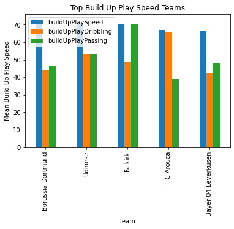

```python
gr1=teams_df.groupby('team').mean().sort_values(['buildUpPlaySpeed'],ascending=False).head(5)
gr1.plot(kind='bar');
plt.title('Top Build Up Play Speed Teams')
plt.ylabel('Mean Build Up Play Speed');
```

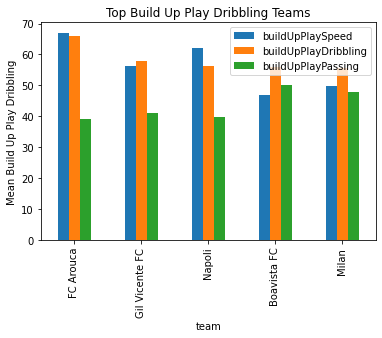

```python
gr2=teams_df.groupby('team').mean().sort_values(['buildUpPlayDribbling'],ascending=False).head(5)
gr2.plot(kind='bar');
plt.title('Top Build Up Play Dribbling Teams')
plt.ylabel('Mean Build Up Play Dribbling');
```

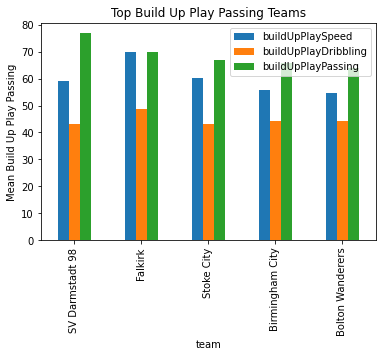

```python
gr3=teams_df.groupby('team').mean().sort_values(['buildUpPlayPassing'],ascending=False).head(5)
gr3.plot(kind='bar');
plt.title('Top Build Up Play Passing Teams')
plt.ylabel('Mean Build Up Play Passing');
```

### Research Question 2: Which players had the most penalties?

```python
# this query gets the palyer and player attributes tables joined them gets the players with most penalties

# players_query='''
#                 select DISTINCT p.player_name,penalties from player p
#                 join player_attributes pa
#                 on pa.player_api_id=p.player_api_id
#                 order by 2 desc
#                 limit (5)
#             '''
# top_penalties_players=pd.read_sql_query(players_query,db)
# top_penalties_players=top_penalties_players.to_csv('players.csv',index=False)

top_penalties_players=pd.read_csv('players.csv')
top_penalties_players.head()
```

|  | player_name | penalties |
| --- | --- | --- |
| 0 | Rickie Lambert | 96 |
| 1 | Andrea Pirlo | 95 |
| 2 | Mario Balotelli | 95 |
| 3 | Paul Scholes | 95 |
| 4 | Rickie Lambert | 95 |

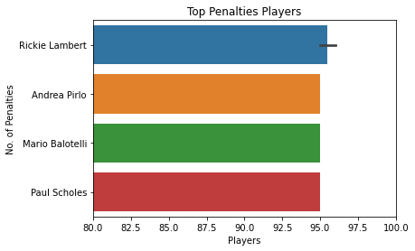

```python
ax=sns.barplot(y="player_name", x="penalties",data=top_penalties_players)
ax.set(xlabel='Players', ylabel='No. of Penalties',title='Top Penalties Players')
plt.xlim(80,100);
```

This query shows which players had the most penaltites and the most one is **Rickie Lambert**

### Research Question 3: What team attributes lead to the most victories?

```python
# this query joins country,league,match,team,team attributes tables together
# and shows the team attributes in every match for both home and away team then write the output to winners.csv file

# winners_query=""" with sub as (
#                                 select DISTINCT c.name country,l.name league,ht.team_long_name home_team,at.team_long_name away_team,home_team_goal,away_team_goal,CASE when home_team_goal>away_team_goal then ht.team_long_name when home_team_goal<away_team_goal then at.team_long_name else 'draw' end as Winner,m.date match_date,season,stage,h_ta.date team_atrribute_date,h_ta.chanceCreationPassing,h_ta.chanceCreationCrossing,h_ta.chanceCreationShooting,h_ta.defencePressure,h_ta.defenceAggression,h_ta.defenceTeamWidth,a_ta.date team_atrribute_date,a_ta.chanceCreationPassing,a_ta.chanceCreationCrossing,a_ta.chanceCreationShooting,a_ta.defencePressure,a_ta.defenceAggression,a_ta.defenceTeamWidth from match m
#                                 join country c on m.country_id=c.id
#                                 join League l on m.league_id=l.id
#                                 join team ht on ht.team_api_id=m.home_team_api_id
#                                 join team at on at.team_api_id=m.away_team_api_id
#                                 join Team_Attributes h_ta on h_ta.team_api_id=m.home_team_api_id
#                                 join Team_Attributes a_ta on a_ta.team_api_id=m.away_team_api_id
#                     )
#                     select * from sub
#                     where Winner!='draw'
#                 """
# winners_df=pd.read_sql_query(winners_query,db)
# winners_df.to_csv('winners.csv',index=False)

winners_df=pd.read_csv('winners.csv')
```

```python
winners_df.head(2)
```

|  | country | league | home_team | away_team | home_team_goal | away_team_goal | Winner | match_date | season | stage | ... | defencePressure | defenceAggression | defenceTeamWidth | team_atrribute_date:1 | chanceCreationPassing:1 | chanceCreationCrossing:1 | chanceCreationShooting:1 | defencePressure:1 | defenceAggression:1 | defenceTeamWidth:1 |
| --- | --- | --- | --- | --- | --- | --- | --- | --- | --- | --- | --- | --- | --- | --- | --- | --- | --- | --- | --- | --- | --- |
| 0 | Belgium | Belgium Jupiler League | KSV Cercle Brugge | RSC Anderlecht | 0 | 3 | RSC Anderlecht | 2008-08-16 00:00:00 | 2008/2009 | 1 | ... | 65 | 60 | 70 | 2010-02-22 00:00:00 | 70 | 50 | 60 | 70 | 50 | 70 |
| 1 | Belgium | Belgium Jupiler League | KSV Cercle Brugge | RSC Anderlecht | 0 | 3 | RSC Anderlecht | 2008-08-16 00:00:00 | 2008/2009 | 1 | ... | 65 | 60 | 70 | 2011-02-22 00:00:00 | 70 | 50 | 60 | 70 | 50 | 70 |

2 rows × 24 columns

```python
#creating a new column to indicate if the home team scored or no
home_scr = []

for g in winners_df.home_team_goal.tolist():
    if g > 0:
        home_scr.append('scored')
    else:
        home_scr.append('zero score')

winners_df['home_scr'] = np.array(home_scr)

winners_df.head()
```

|  | country | league | home_team | away_team | home_team_goal | away_team_goal | Winner | match_date | season | stage | ... | defenceAggression | defenceTeamWidth | team_atrribute_date:1 | chanceCreationPassing:1 | chanceCreationCrossing:1 | chanceCreationShooting:1 | defencePressure:1 | defenceAggression:1 | defenceTeamWidth:1 | home_scr |
| --- | --- | --- | --- | --- | --- | --- | --- | --- | --- | --- | --- | --- | --- | --- | --- | --- | --- | --- | --- | --- | --- |
| 0 | Belgium | Belgium Jupiler League | KSV Cercle Brugge | RSC Anderlecht | 0 | 3 | RSC Anderlecht | 2008-08-16 00:00:00 | 2008/2009 | 1 | ... | 60 | 70 | 2010-02-22 00:00:00 | 70 | 50 | 60 | 70 | 50 | 70 | zero score |
| 1 | Belgium | Belgium Jupiler League | KSV Cercle Brugge | RSC Anderlecht | 0 | 3 | RSC Anderlecht | 2008-08-16 00:00:00 | 2008/2009 | 1 | ... | 60 | 70 | 2011-02-22 00:00:00 | 70 | 50 | 60 | 70 | 50 | 70 | zero score |
| 2 | Belgium | Belgium Jupiler League | KSV Cercle Brugge | RSC Anderlecht | 0 | 3 | RSC Anderlecht | 2008-08-16 00:00:00 | 2008/2009 | 1 | ... | 60 | 70 | 2012-02-22 00:00:00 | 53 | 57 | 47 | 45 | 43 | 52 | zero score |
| 3 | Belgium | Belgium Jupiler League | KSV Cercle Brugge | RSC Anderlecht | 0 | 3 | RSC Anderlecht | 2008-08-16 00:00:00 | 2008/2009 | 1 | ... | 60 | 70 | 2013-09-20 00:00:00 | 68 | 67 | 47 | 60 | 43 | 65 | zero score |
| 4 | Belgium | Belgium Jupiler League | KSV Cercle Brugge | RSC Anderlecht | 0 | 3 | RSC Anderlecht | 2008-08-16 00:00:00 | 2008/2009 | 1 | ... | 60 | 70 | 2014-09-19 00:00:00 | 60 | 53 | 47 | 60 | 50 | 65 | zero score |

5 rows × 25 columns

```python
# filtering the df to get only home team winners and dropping the away team attributes
winners_df=pd.read_csv('winners.csv')
home_winners_df=winners_df.query('Winner == home_team')
home_winners_df.drop(home_winners_df.columns[17:],axis=1 , inplace=True)
home_winners_df.head(3)
```

|  | country | league | home_team | away_team | home_team_goal | away_team_goal | Winner | match_date | season | stage | team_atrribute_date | chanceCreationPassing | chanceCreationCrossing | chanceCreationShooting | defencePressure | defenceAggression | defenceTeamWidth |
| --- | --- | --- | --- | --- | --- | --- | --- | --- | --- | --- | --- | --- | --- | --- | --- | --- | --- |
| 36 | Belgium | Belgium Jupiler League | KAA Gent | RAEC Mons | 5 | 0 | KAA Gent | 2008-08-17 00:00:00 | 2008/2009 | 1 | 2010-02-22 00:00:00 | 60 | 50 | 60 | 45 | 50 | 40 |
| 37 | Belgium | Belgium Jupiler League | KAA Gent | RAEC Mons | 5 | 0 | KAA Gent | 2008-08-17 00:00:00 | 2008/2009 | 1 | 2010-02-22 00:00:00 | 60 | 50 | 60 | 45 | 50 | 40 |
| 38 | Belgium | Belgium Jupiler League | KAA Gent | RAEC Mons | 5 | 0 | KAA Gent | 2008-08-17 00:00:00 | 2008/2009 | 1 | 2010-02-22 00:00:00 | 60 | 50 | 60 | 45 | 50 | 40 |

```python
group1=home_winners_df.groupby('Winner').mean()
group1.head()
```

| Winner | home_team_goal | away_team_goal | stage | chanceCreationPassing | chanceCreationCrossing | chanceCreationShooting | defencePressure | defenceAggression | defenceTeamWidth |
| --- | --- | --- | --- | --- | --- | --- | --- | --- | --- |
| 1. FC Kaiserslautern | 2.625000 | 0.500000 | 16.750000 | 47.166667 | 62.000000 | 59.666667 | 46.833333 | 52.833333 | 55.166667 |
| 1. FC Köln | 2.177419 | 0.521505 | 17.994624 | 55.166667 | 41.666667 | 59.000000 | 45.000000 | 51.166667 | 60.833333 |
| 1. FC Nürnberg | 2.303371 | 0.528090 | 18.865169 | 50.500000 | 53.000000 | 59.166667 | 43.333333 | 50.500000 | 44.000000 |
| 1. FSV Mainz 05 | 2.310976 | 0.493902 | 16.439024 | 53.000000 | 47.666667 | 54.500000 | 52.500000 | 62.500000 | 49.666667 |
| AC Ajaccio | 1.870968 | 0.569892 | 20.989247 | 50.333333 | 40.666667 | 52.166667 | 37.833333 | 50.500000 | 48.666667 |

```python
test=home_winners_df.mean()
```

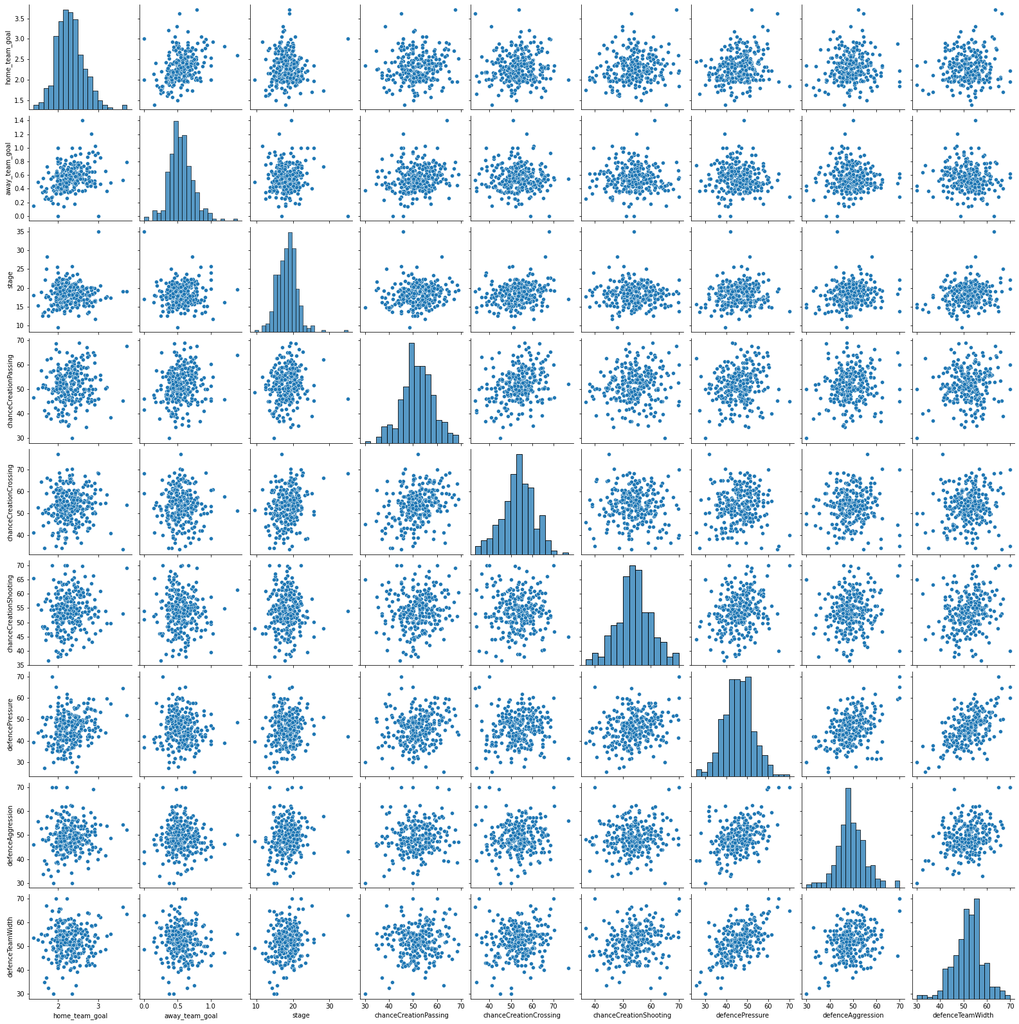

```python
sns.pairplot(group1);
```

From the figures it's showing that the home teams most effective attributes for winning are:

- Defence Pressure,
- Defence Aggression
- Defence TeamWidth

```python
# filtering the df to get only away team winners and dropping the home team attributes
winners_df=pd.read_csv('winners.csv')
away_winners_df=winners_df.query('Winner == away_team')
away_winners_df.drop(away_winners_df.columns[10:17],axis=1 , inplace=True)
away_winners_df.head(3)
```

|  | country | league | home_team | away_team | home_team_goal | away_team_goal | Winner | match_date | season | stage | team_atrribute_date:1 | chanceCreationPassing:1 | chanceCreationCrossing:1 | chanceCreationShooting:1 | defencePressure:1 | defenceAggression:1 | defenceTeamWidth:1 |
| --- | --- | --- | --- | --- | --- | --- | --- | --- | --- | --- | --- | --- | --- | --- | --- | --- | --- |
| 0 | Belgium | Belgium Jupiler League | KSV Cercle Brugge | RSC Anderlecht | 0 | 3 | RSC Anderlecht | 2008-08-16 00:00:00 | 2008/2009 | 1 | 2010-02-22 00:00:00 | 70 | 50 | 60 | 70 | 50 | 70 |
| 1 | Belgium | Belgium Jupiler League | KSV Cercle Brugge | RSC Anderlecht | 0 | 3 | RSC Anderlecht | 2008-08-16 00:00:00 | 2008/2009 | 1 | 2011-02-22 00:00:00 | 70 | 50 | 60 | 70 | 50 | 70 |
| 2 | Belgium | Belgium Jupiler League | KSV Cercle Brugge | RSC Anderlecht | 0 | 3 | RSC Anderlecht | 2008-08-16 00:00:00 | 2008/2009 | 1 | 2012-02-22 00:00:00 | 53 | 57 | 47 | 45 | 43 | 52 |

```python
group2=away_winners_df.groupby('Winner').mean()
group2.head()
```

| Winner | home_team_goal | away_team_goal | stage | chanceCreationPassing:1 | chanceCreationCrossing:1 | chanceCreationShooting:1 | defencePressure:1 | defenceAggression:1 | defenceTeamWidth:1 |
| --- | --- | --- | --- | --- | --- | --- | --- | --- | --- |
| 1. FC Kaiserslautern | 0.888889 | 2.222222 | 21.333333 | 47.166667 | 62.000000 | 59.666667 | 46.833333 | 52.833333 | 55.166667 |
| 1. FC Köln | 0.722892 | 2.289157 | 15.734940 | 55.166667 | 41.666667 | 59.000000 | 45.000000 | 51.166667 | 60.833333 |
| 1. FC Nürnberg | 0.842105 | 2.263158 | 18.894737 | 50.500000 | 53.000000 | 59.166667 | 43.333333 | 50.500000 | 44.000000 |
| 1. FSV Mainz 05 | 0.974093 | 2.440415 | 16.611399 | 53.000000 | 47.666667 | 54.500000 | 52.500000 | 62.500000 | 49.666667 |
| AC Ajaccio | 0.833333 | 2.333333 | 20.166667 | 50.333333 | 40.666667 | 52.166667 | 37.833333 | 50.500000 | 48.666667 |

[figure not shown]

```python
sns.pairplot(group2);
```

[output not shown]

From the figures it's showing that the away teams most effective attributes for winning are:

- Defence Pressure,
- Defence Aggression
- Defence TeamWidth
- Chance Creation Shooting

As the positive correlation is clear for each one of them and of course the away team goal also has a positive correlation with the victory.

## Conclusions

The results here showed the required answers for the questions we had by shaping the needed data frame the best fit the answer of each question.

Some Challanges and limitations:

- Many columns in the Match table are empty it would make analysis more accurate if these values were recorded.
- The DB has many unuseful records and is kind of intensive but sql helped in solving that issue.
- As the DB has many tables after doing some joins the output csv files were big in size

### Refrences I used

- Stackoverflow
- Github
- Pandas and Seaborn docs